# COVID-19

IST707 Final Project

Devyn Hughes, Lisa GreenPope

March 22, 2024

# Introduction

The COVID-19 pandemic is something that has impacted the lives of billions of people across the globe. It began in December 2019, when a small cluster of individuals who had shopped at a certain market in Wuhan, China began to experience symptoms of an unknown respiratory illness. Within a few weeks, the virus causing the illness was identified as a novel Coronavirus, which was first named SARS CoV-2, and then eventually COVID-19. It soon began to spread worldwide, with the first confirmed case appearing in the United States on January 20, 2020. The US and other countries responded to the outbreak in a variety of ways, starting with isolation and quarantine, travel restrictions, the declaration of Public Health Emergencies, social distancing and masking measures, and eventually progressing to more severe limitations such as school closures and stay-at-home orders. By April of 2020 there had been over 18,000 deaths due to COVID-19 in the United States, and by June there were over 2 million deaths.

Throughout the global torment of COVID-19, data was always constantly being collected each day. We all know that data science and analytics are key tools to today’s society. Thus, how can we use this process for this potent and deadly virus? Before moving into that, questions had to be asked about the virus. What are the discerning factors between different countries? How did other countries handle the virus? Was there a particular infection rate that differed from others? There are hundreds of questions with hundreds of answers. Joshua Lederberg said, “The single, biggest threat to man’s continued dominance on the planet is the virus.”. Therefore, it is important to be able to understand, acknowledge, learn, and improve in the coming years to make sure economies can handle another issue if one arose.

When COVID-19 hit, testing was an important feature of curbing the spread of the illness. The more time that passed, the more detrimental it became for society. The virus had its own defense mechanism against testing as handle such an infectious terrorist is dangerous in its own right. Over time, countries were able to find ways to assess for COVID-19 which went from private testing sites, to public testing sites, to home testing kits. This was a huge step for the war against this resilient bane of existence. From further gather, testing, and ingenuity, vaccinations were created to top the spread of the illness. Many were in development and soon became public in December of2020 to those who were present around the virus on a daily basis, the healthcare workers.

However, one idea that comes to mind is, how can we improve from our faults? How do identify our issues and make better protocols and procedures for the next crisis? COVID-19 has now been considered as something similar to a common cold or a mild flu. There are no more needs of segregating oneself from society for 2 weeks like before. The CDC has stated that someone can be back to work in just a couple of days after experiencing symptoms now. With the data collected, we are looking to derive a problem statement that evaluates more about COVID-19 regarding many different factors across the world.

## Problem Statement

The last time the world experienced a global pandemic was approximately 100 years before the current one, in 1918-1920. The Spanish Flu pandemic was responsible for somewhere between 50-100 million deaths worldwide. In the early 1900’s, society did not have the advanced healthcare system that is seen today, nor was the field of epidemiology as advanced as it is today. Even with the advanced knowledge available in 2020, the world was still not prepared for a pandemic of this scale. It will be important for public health officials to learn as much as possible from COVID-19, in order to be prepared for any future pandemics.

In this study, the mortality (death rate), and incidence (case rate) of the disease will be the primary outcomes assessed. The available data will be evaluated to look for any trends that identify which factors lead to increased mortality and increased incidence of disease.

# About the Data

The COVID-19 pandemic generated massive amounts of data. One important dataset comes from the UK based Global Change Data Lab’s “Our World in Data” (OWID) project. The OWID project tracked key indicators of COVID-19 at the global level, and made that information available to the public. In this analysis, the OWID COVID-19 dataset as of March 5, 2022 was utilized. This dataset includes 166,326 observations of 67 different variables. Each observation represents a single country’s status on a particular day, ranging from Afghanistan on 2/24/2020 to Zimbabwe on 3/5/22. For each country’s daily observation, the 67 attributes measured fall into several key categories including:

- Country attributes
- Case counts
- Epidemiological factors
- Deaths
- Hospital data
- Testing data
- Vaccination data

## Data Preparation

In data science, data cleaning and preparation is often the most labor intensive part of any analysis. This study is no different. One important issue to overcome with this data set is identifying how much data is missing, and then deciding how to handle those NA values. A good rule of thumb is that if over 5% of the data is missing, it may not be reliable. In this dataset, there are many observations and many attributes with well over 5% of the data missing.

Some data is missing due to the timeframe of the pandemic itself. For example, there is limited new case data until late January 2020, and no vaccination data until December 2020. There are some data points, such as those related to ICU admissions that are lacking across the board.

Another important issue is normalizing the data. This data includes both raw counts and rates, some of which are smoothed. The raw counts may be misleading because a country with a large population will most likely have more cases and deaths than a country with a small population. It would be more meaningful to compare the rates of disease and death, than to compare the actual counts. For this reason, the variables showing raw counts were excluded from analysis. Smoothed variables were also excluded, except for those related to vaccinations because in this data set, vaccination rates are only presented as smoothed.

### Load libraries

The first step of any data analysis project is to load all of the packages needed for analysis. In this study, a variety of packages used for data pre-processing, machine learning and visualization will be loaded.

```r
start_time <- Sys.time() #adding this just to track how long this takes

library(tidyverse, quietly = TRUE) #for data preparation
library(arules, quietly = TRUE) #for association rule mining
library(arulesViz, quietly = TRUE) #for association rule mining
library(lsa, quietly = TRUE) #for distance measures in clustering
library(cluster, quietly = TRUE) #for clustering
library(foreign, quietly = TRUE) #to read in arff files
library(factoextra, quietly = TRUE) #helps with hierarchical clustering
library(psych, quietly = TRUE)
library(gridExtra, quietly = TRUE) #to put multiple graphs into one image
library(cowplot, quietly = TRUE) #to put multiple graphs into one image
library(maps, quietly = TRUE) #to load geospatial data for maps
library(caret, quietly = TRUE) #variable importance in decision trees
library(rpart, quietly = TRUE) #helps with decision trees
library(rpart.plot, quietly = TRUE) #decision tree visuals
library(xts, quietly = TRUE) #for time series
library(tseries, quietly = TRUE) #for time series
library(rattle, quietly = TRUE) #for decision tree visualization
library(janitor, quietly = TRUE) #to remove constants in a sparse matrix
library(e1071, quietly = TRUE) #for svm & naive bayes
library(naivebayes, quietly = TRUE)
library(randomForest, quietly = TRUE)
library(ggfortify, quietly = TRUE) #to create principal components analysis plots
library(viridis, quietly = TRUE) #for color scales
library(class, quietly = TRUE) #for knn
library(fastDummies, quietly = TRUE) #to create dummy variables
library(scales, quietly = TRUE) #to format numeric data
```

### Load & Tidy Data

The dataset was downloaded from Our World in Data, and saved as a CSV file.

```r
#Read in the data (if using Devyn's computer)
#covid <- read_csv("C:/Users/Devs PC/OneDrive/Documents/IST 707/owid-covid-data.csv")

#Read in the data (if using Lisa's computer)
covid <- read_csv("owid-covid-data.csv")

#Convert the date column to a date format (not character)
covid$date <- as.Date(covid$date, format = "%m/%d/%Y")

#convert all character columns to factors
covid <- covid %>%
  mutate_if(is.character, as.factor)

#create as a separate dataframe
df <- covid
```

## Exploratory Data Analysis

The COVID-19 dataset used in the analysis has many interesting variables. Before building any machine learning models, the data will be reviewed to look for trends that might inform model development. In particular, variables that impact the daily mortality rate will be assessed.

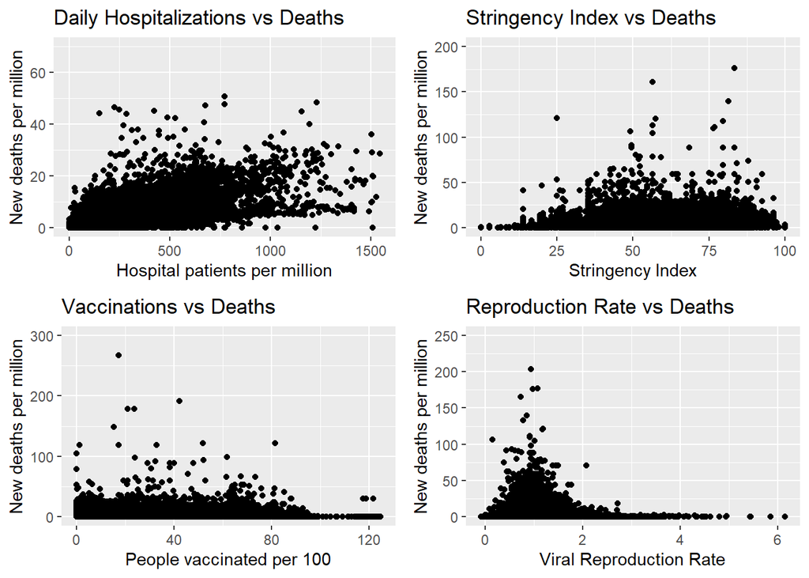

```r
#create several plots
plot_hosp_death <- ggplot(df, aes(hosp_patients_per_million, new_deaths_per_million)) +
  geom_point() +
  coord_cartesian(ylim = c(0, 70)) +
  labs(x = "Hospital patients per million", y = "New deaths per million", title = "Daily Hospitalizations vs Deaths")

plot_string_death <- ggplot(df, aes(stringency_index, new_deaths_per_million)) +
  geom_point() +
  coord_cartesian(ylim = c(0, 200)) +
  labs(x = "Stringency Index", y = "New deaths per million", title = "Stringency Index vs Deaths")

plot_vax_death <- ggplot(df, aes(people_vaccinated_per_hundred, new_deaths_per_million)) +
  geom_point() +
  coord_cartesian(ylim = c(0, 300)) +
  labs(x = "People vaccinated per 100", y = "New deaths per million", title = "Vaccinations vs Deaths")

plot_repro_death <- ggplot(df, aes(reproduction_rate, new_deaths_per_million)) +
  geom_point() +
  coord_cartesian(ylim = c(0, 250)) +
  labs(x = "Viral Reproduction Rate", y = "New deaths per million", title = "Reproduction Rate vs Deaths")

#Visualize all four plots
cowplot::plot_grid(plot_hosp_death, plot_string_death, plot_vax_death, plot_repro_death, ncol = 2, nrow = 2)
```

The four plots above begin to show some interesting trends that can be further explored. The daily mortality rate is the dependent variable in these examples. It does appear that the daily mortality rate increases as the hospitalization rate increases. This is logical, as the more people who become ill enough to require hospitalization, the more people are likely to succumb to the illness.

Deaths and the stringency index also appear to be somewhat positively correlated as well. Recall that the stringency index is a measure of how strict a country was in terms of prevention measures, such as closing schools and public transportation, requiring masking and social distancing and other rules. Using epidemiological knowledge, it may be that the stringency measure is actually the dependent variable, and the more deaths that a country is experiencing, the government for that country may be reacting and enacting more strict regulations.

It is also interesting to note that as vaccinations increased, deaths appear to decrease. This makes sense, as a population approaches herd immunity with a greater portion of it’s population vaccinated, people will be likely to experience less severe illnesses and less death.

The viral reproduction rate refers to how many individuals become ill from one infected individual. This is a measure of how rapidly a virus is spreading in the population. A reproduction number of one means that the rate of infection is likely remaining steady, with each person only infecting one additional person. When the reproduction number is higher, such as 2 or 3, it means that each infected individual is spreading the illness to several people, and the infection could spread exponentially faster. It appears that the death rate is highest when the reproduction number is around 1, which is interesting. When the virus is spreading faster, it is not necessarily more deadly. This is supported by the science as well, because some strains of the virus that were circulating were able to spread more rapidly but did not cause as severe of illness.

Deaths are often a function of how many cases are occurring, so the stringency index and cases will also be reviewed.

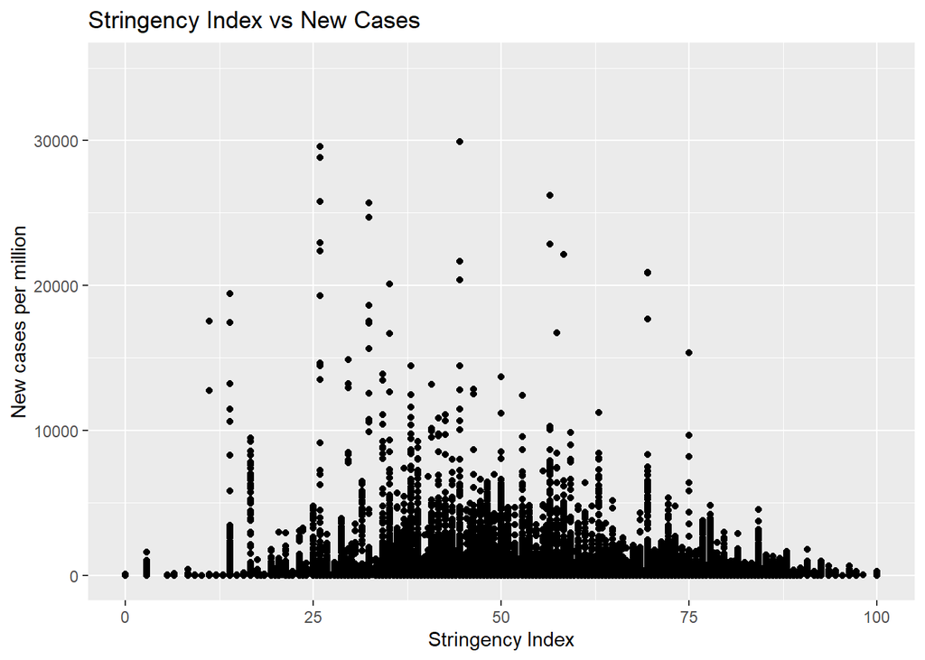

```r
#Plot stringency against new cases
ggplot(df, aes(stringency_index, new_cases_per_million)) +
  geom_point() +
  coord_cartesian(ylim = c(0, 35000))+
  labs(x = "Stringency Index", y = "New cases per million", title = "Stringency Index vs New Cases")
```

It is interesting to note that the number of cases occurring as a function of the stringency index appears to be more of a bell curve in shape. As discussed above, the stringency index may actually be a reactive measure, where as deaths increase, a country’s response becomes more strict. That trend is not necessarily seen with cases. The number of new cases per day seems to taper out at both the low and high end of the stringency index.

### Outcome Selection: Mortality

Now that some basic exploratory data analysis has been conducted, mortality does appear to be a good outcome measure to use. There are some interesting trends that can be explored. Before that can be certain, it is important to assess the data quality, such as looking at the overall distribution, and how much data is missing.

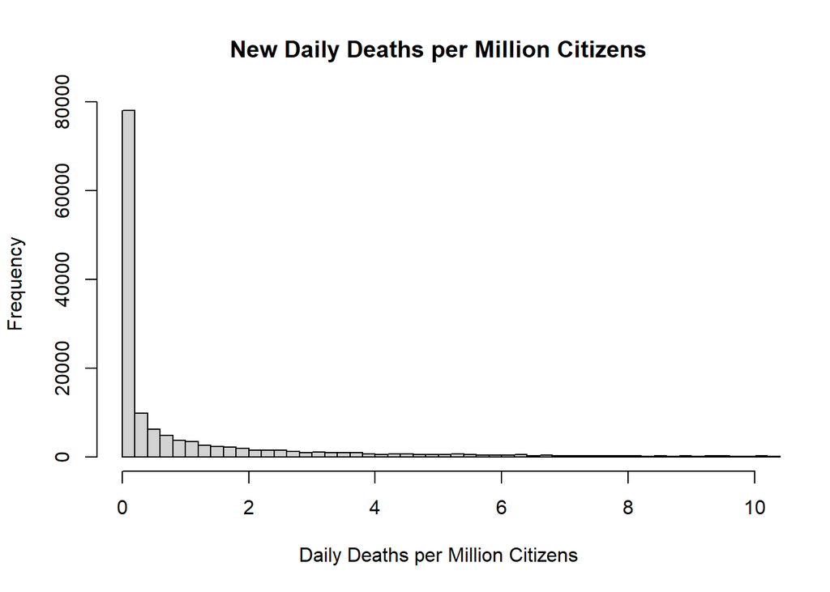

```r
#Create histogram to view distribution of mortality rate
#Limit the x-axis range for easier viewing
hist(df$new_deaths_per_million, breaks = 2000, xlim = c(0,10), main = "New Daily Deaths per Million Citizens", xlab = "Daily Deaths per Million Citizens")
```

```r
#Calculate range of daily mortality rate
range(na.omit(df$new_deaths_per_million))
```

```
## [1]   0.000 453.772
```

```r
#Calculate mean of daily mortality rate
mean(na.omit(df$new_deaths_per_million))
```

```
## [1] 1.68681
```

```r
#identify the 10% quantiles of daily mortality rate
quantile(df$new_deaths_per_million, probs = seq(0, 1, 1/10), na.rm = TRUE)
```

```
##      0%     10%     20%     30%     40%     50%     60%     70%     80%     90%
##   0.000   0.000   0.000   0.000   0.000   0.127   0.373   0.918   2.014   4.808
##    100%
## 453.772
```

```r
#what percent of daily death rates are NA?
1-(length(na.omit(df$new_deaths_per_million))/length(df$new_deaths_per_million))
```

```
## [1] 0.1297692
```

```r
#how many of the daily death rate observations are outliers?
length(boxplot(df$new_deaths_per_million)$out)
```

```
## [1] 19841
```

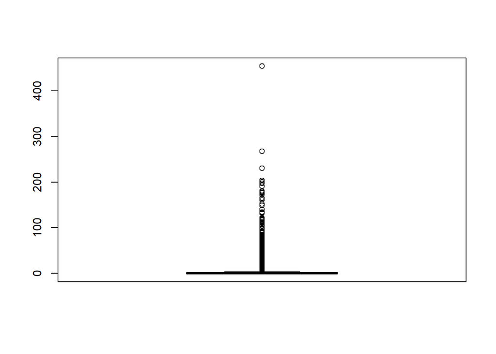

```
## [1] 0.1370784
```

```r
#view boxplot to visualize outliers
#What percentage are considered outliers?
length(boxplot(df$new_deaths_per_million)$out)/length(na.omit(df$new_deaths_per_million))
```

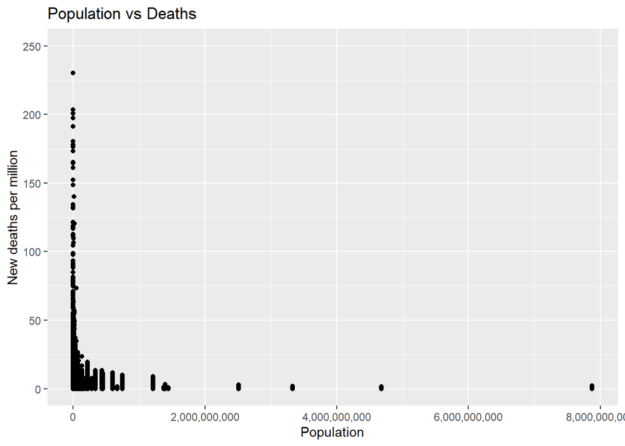

```r
#Visualize population vs mortality rate to see if the outliers are primarily small countries (small numbers issue)
plot_pop_death <- ggplot(df, aes(population, new_deaths_per_million)) +
  geom_point() +
  coord_cartesian(ylim = c(0, 250)) +
  labs(x = "Population", y = "New deaths per million", title = "Population vs Deaths") +
  scale_x_continuous(labels = comma)
plot_pop_death
```

Although the range for daily mortality ranges from 0 to 453 deaths per million citizens, the distribution is very skewed. The mean is 1.68 per million, per day, but it is not until after the 70th percentile that the death rate even reaches 1 per million per day. In addition to that, 13% of the values are NAs, and another 13% are outliers (beyond 1.5x the IQR). From reviewing the dataframe, the outliers appear to be coming from countries with smaller populations, where even one deaths might make the rate (per million) appear artificially high. This is one factor that will need to be considered during the analysis.

### Outcome Selection: Cases

The distribution of cases will also be reviewed, to assess if that could be used as an outcome variable as well.

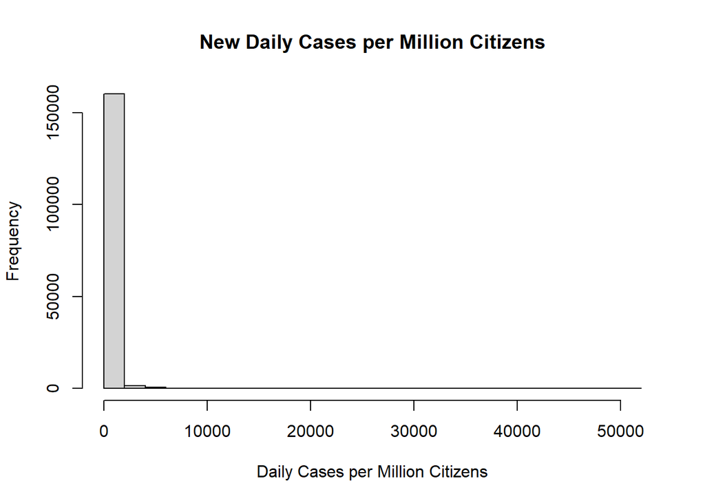

```r
#Create histogram to view distribution of case rate
hist(df$new_cases_per_million, main = "New Daily Cases per Million Citizens", xlab = "Daily Cases per Million Citizens")
```

```r
#Calculate range for daily case rate
range(na.omit(df$new_cases_per_million))
```

```
## [1]     0.00 51427.49
```

```r
#Calculate mean for daily case rate
mean(na.omit(df$new_cases_per_million))
```

```
## [1] 166.4315
```

```r
#identify the 10% quantiles of daily case rate
quantile(df$new_cases_per_million, probs = seq(0, 1, 1/10), na.rm = TRUE)
```

```
##         0%        10%        20%        30%        40%        50%        60%
##     0.0000     0.0000     0.0000     0.5820     3.4760    11.4390    30.8250
##        70%        80%        90%       100%
##    69.2790   149.9628   350.4900 51427.4910
```

```r
#Count non-blank daily case rate observations
length(na.omit(df$new_cases_per_million))
```

```
## [1] 162375
```

```r
#count total observations (including blanks) for daily case rate
length(df$new_cases_per_million)
```

```
## [1] 166326
```

```r
#what percent of daily case rates are NA?
1-(length(na.omit(df$new_cases_per_million))/length(df$new_cases_per_million))
```

```
## [1] 0.02375455
```

The distribution for cases is similar to deaths, there is a strong skew with a large portion of the days with numbers at either 0 or very close to 0 even though the mean is 166 cases per million, per day. This is due to some very high outliers, with the range of values being from 0 to 51,427. One positive thing about the case rate data is that there are relatively fewer blank values, with only 2% NAs.

### Worldwide Geography

Next, the data will be viewed through the lens of geography. One particular date was chosen to create a cross section and review the daily number of cases per million citizens on that day, broken down by continent for easier visualization.

```r
#Create a table with just one month
df_Aug2121 <- df %>%
  filter(date == "2021-08-21") %>%
  filter(!is.na(continent))

#count the number of countries reporting data
length(unique(df_Aug2121$location))
```

```
## [1] 224
```

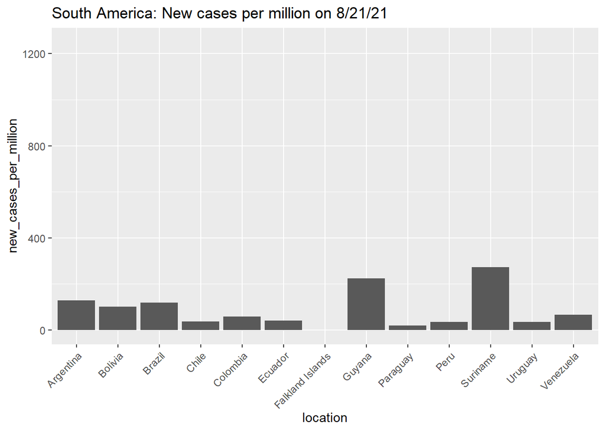

```r
#Create a plot of cases in South America
ggplot(df_Aug2121[df_Aug2121$continent=="South America",], aes(location, new_cases_per_million)) +
  geom_col() +
  labs(title = "South America: New cases per million on 8/21/21") +
  theme(axis.text.x = element_text(angle = 45, vjust = 1, hjust=1)) +
  ylim(0,1250)
```

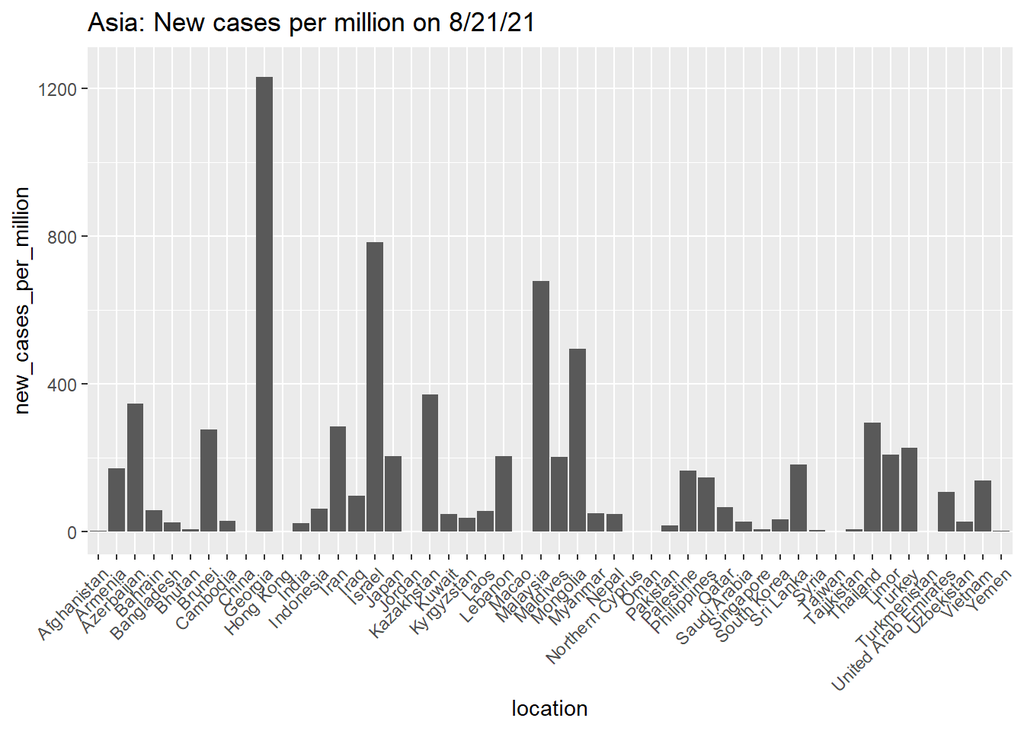

```r
#Create a plot of cases in Asia
ggplot(df_Aug2121[df_Aug2121$continent=="Asia",], aes(location, new_cases_per_million)) +
  geom_col() +
  labs(title = "Asia: New cases per million on 8/21/21") +
  theme(axis.text.x = element_text(angle = 45, vjust = 1, hjust=1))+
  ylim(0,1250)
```

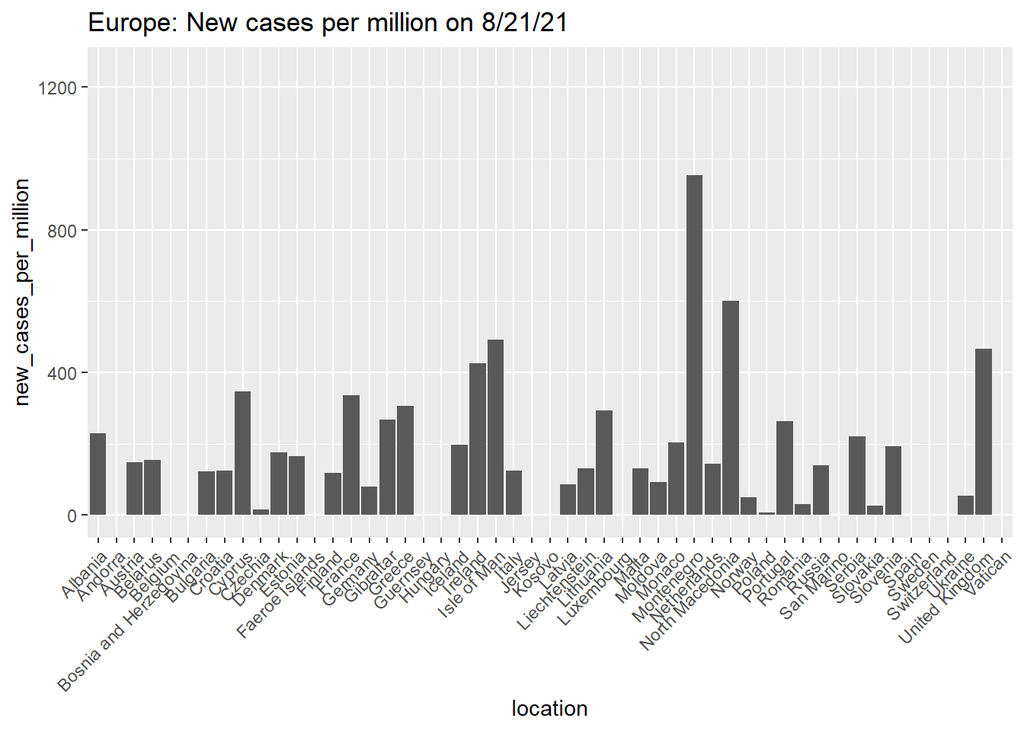

```r
#Create a plot of cases in Europe
ggplot(df_Aug2121[df_Aug2121$continent=="Europe",], aes(location, new_cases_per_million)) +
  geom_col() +
  labs(title = "Europe: New cases per million on 8/21/21") +
  theme(axis.text.x = element_text(angle = 45, vjust = 1, hjust=1)) +
  ylim(0,1250)
```

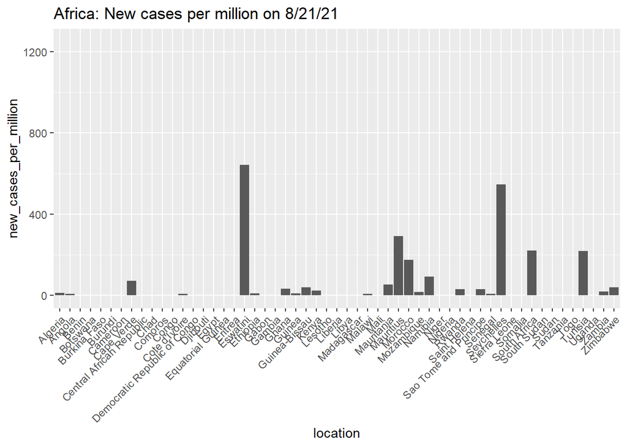

```r
#Create a plot of cases in Africa
ggplot(df_Aug2121[df_Aug2121$continent=="Africa",], aes(location, new_cases_per_million)) +
  geom_col() +
  labs(title = "Africa: New cases per million on 8/21/21") +
  theme(axis.text.x = element_text(angle = 45, vjust = 1, hjust=1)) +
  ylim(0,1250)
```

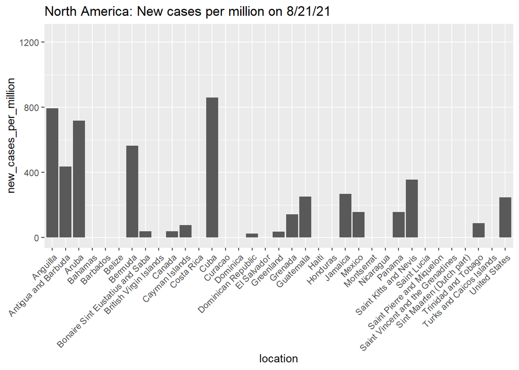

```r
#Create a plot of cases in North America
ggplot(df_Aug2121[df_Aug2121$continent=="North America",], aes(location, new_cases_per_million)) +
  geom_col() +
  labs(title = "North America: New cases per million on 8/21/21") +
  theme(axis.text.x = element_text(angle = 45, vjust = 1, hjust=1)) +
  ylim(0,1250)
```

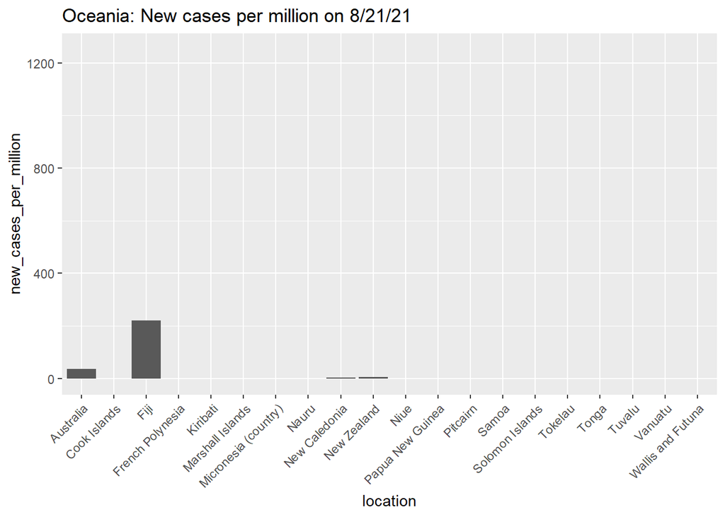

```r
#Create a plot of cases in Oceania
ggplot(df_Aug2121[df_Aug2121$continent=="Oceania",], aes(location, new_cases_per_million)) +
  geom_col() +
  labs(title = "Oceania: New cases per million on 8/21/21") +
  theme(axis.text.x = element_text(angle = 45, vjust = 1, hjust=1)) +
  ylim(0,1250)
```

The charts above were all scaled similarly so that they could be compared. It’s clear that there is a wide variety of case rates on that day, with many countries showing no cases, and some showing over 1,000 cases per million citizens.

### United States

Next, the data will be further sliced and diced to look at one particular country over time. In this case, we will review data from the United States .

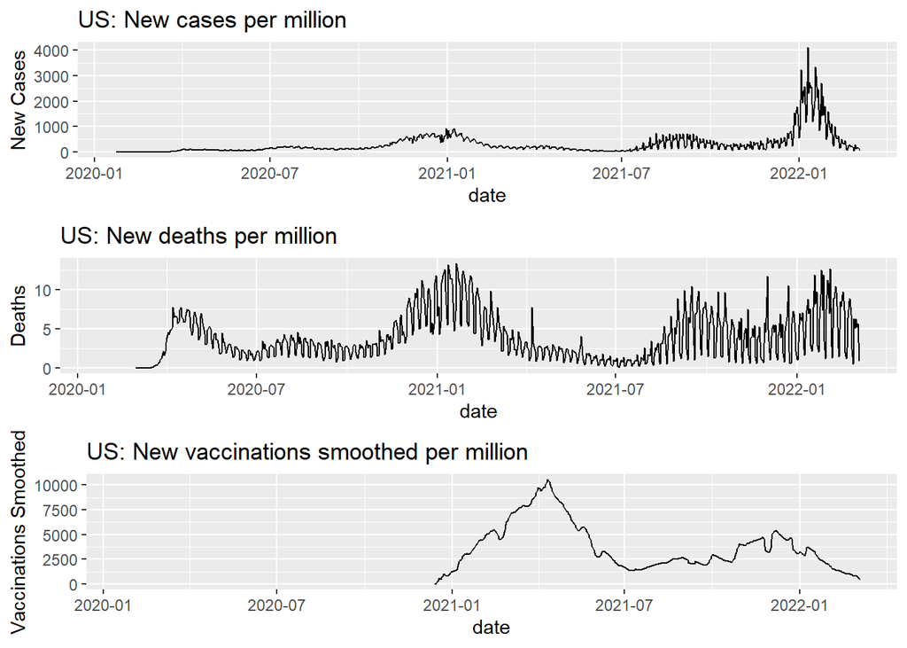

```r
df_USA <- df %>%
  filter(location == "United States")

plotUSCases <- ggplot(df_USA, aes(x = date, y = new_cases_per_million)) +
  geom_line() +
  labs(title = "US: New cases per million", y = "New Cases")

plotUSdeaths <- ggplot(df_USA, aes(x = date, y = new_deaths_per_million)) +
  geom_line() +
  labs(title = "US: New deaths per million", y = "Deaths")

plotUSvax <- ggplot(df_USA, aes(x = date, y = new_vaccinations_smoothed_per_million)) +
  geom_line() +
  labs(title = "US: New vaccinations smoothed per million",
       y = "Vaccinations Smoothed")

cowplot::plot_grid(plotUSCases, plotUSdeaths, plotUSvax, ncol = 1, nrow = 3)
```

The time series data above shows several interesting trends. First, it can be seen that the number of cases had some seasonal spikes around January 2021 and January 2022. Additionally, there are smaller, more frequent fluctuations in the data as well. This is likely due to reporting structures, where more data was reported on weekdays than on weekends, so case and death rates seemed artificially low on weekends. A final interesting point is that the introduction of vaccinations does not occur until the end of 2020, so there is no data available prior to that time point.

# Models

## Unsupervised Learning: Clustering

Creating this table to get the demographic data for each country, so we can cluster them. We’re collapsing it down using distinct() so that there is no time series data here, just one line per country. We’ll drop any country that has an NA value in one of these areas, because that messes up our k-means clustering later.

```r
#Create dataframe by country
df_covid_country <- df %>%
  distinct(location, .keep_all = TRUE) %>%
  select(continent,
          location,
          hospital_beds_per_thousand,
          life_expectancy,
          human_development_index,
          gdp_per_capita,
          extreme_poverty,
          median_age)%>%
  drop_na()


#Make an unlabeled version
df_covid_country_UL <- df_covid_country[,3:8]

#Make the rownames the labels, it will help later with the visualization
rownames(df_covid_country_UL)<- df_covid_country$location
#Check for NAs
sum(is.na(df_covid_country_UL))
```

```
## [1] 0
```

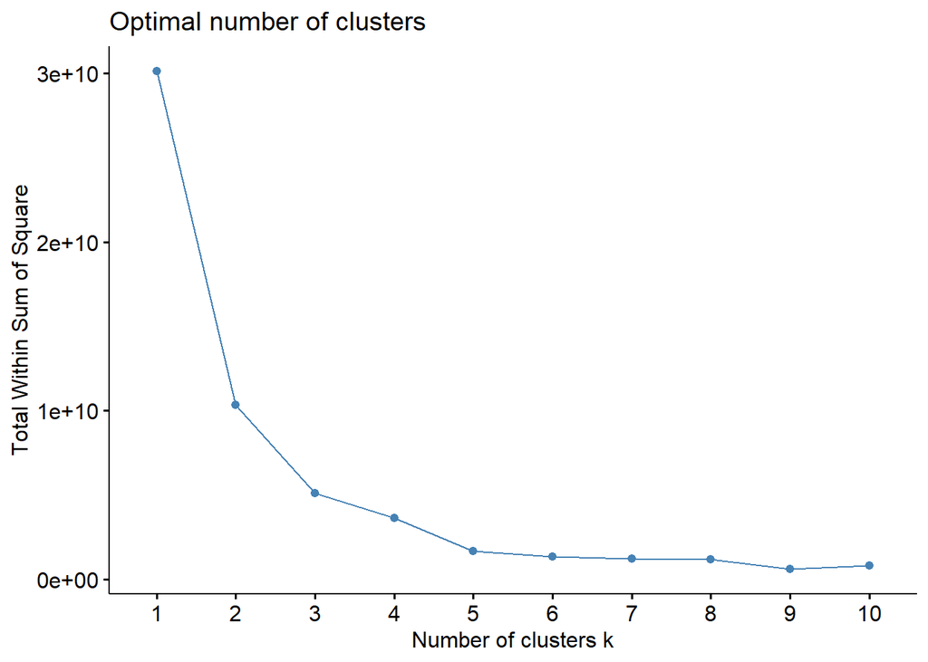

```r
#elbow method to decide how many clusters to use
fviz_nbclust(df_covid_country_UL, kmeans, method = "wss")
```

```r
#Create a k-means model
set.seed(9)
df_covid_country_KM <- kmeans(df_covid_country_UL, 3)

#view details about the model
df_covid_country_KM[2:9]
```

```
## $centers
##   hospital_beds_per_thousand life_expectancy human_development_index
## 1                   4.540393        78.16429               0.8510000
## 2                   1.994300        70.03729               0.6453857
## 3                   3.710909        81.95818               0.9376364
##   gdp_per_capita extreme_poverty median_age
## 1      26473.640       0.9321429   38.86071
## 2       6894.794      17.1014286   26.10714
## 3      54319.553       0.4181818   40.22727
##
## $totss
## [1] 30095578335
##
## $withinss
## [1]  985512771 1673376830 2464530872
##
## $tot.withinss
## [1] 5123420473
##
## $betweenss
## [1] 24972157862
##
## $size
## [1] 28 70 11
##
## $iter
## [1] 2
##
## $ifault
## [1] 0
```

```r
#add the new clusters back to the original data
df_covid_country <- data.frame(df_covid_country, cluster = df_covid_country_KM$cluster)
```

For our clustering, an optimizing method was used to determine the number of clusters needed for this evaluation. From 1 to 10, we saw that a total of 3 clusters seemed to yield the most decisive information for all of our data. Once again, any countries that had a yield of “NA” were removed.

### Map of countries in each demographic cluster

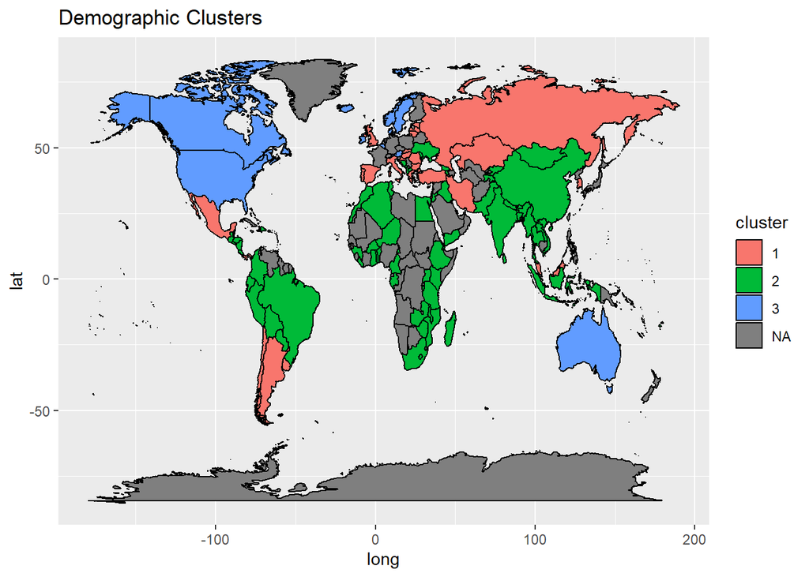

```r
#load in the geospatial data
world_map <- map_data("world")

#add a column to df_covid_country where country is labeled as "region" so it will merge with the map data
df_covid_country$region <- df_covid_country$location

#change region to USA instead of United States so it can merge
df_covid_country$region <- str_replace(df_covid_country$region, "United States", "USA")
df_covid_country$region <- str_replace(df_covid_country$region, "United Kingdom", "UK")

#merge it with the df_covid_country data
merged_world <- full_join(world_map, df_covid_country, by = "region")

#make cluster a factor, when we merged them cluster was formatted as numeric which made the map have a color scale instead of discrete colors
merged_world$cluster <- as.factor(merged_world$cluster)

#create the map
ggplot() +
  geom_polygon(data = merged_world, aes(x=long, y=lat, group=group, fill = cluster), color = "black") +
  labs(title = "Demographic Clusters")
```

### Box plots for country demographic clusters

There are 3 clusters, with 6 different metrics that contributed

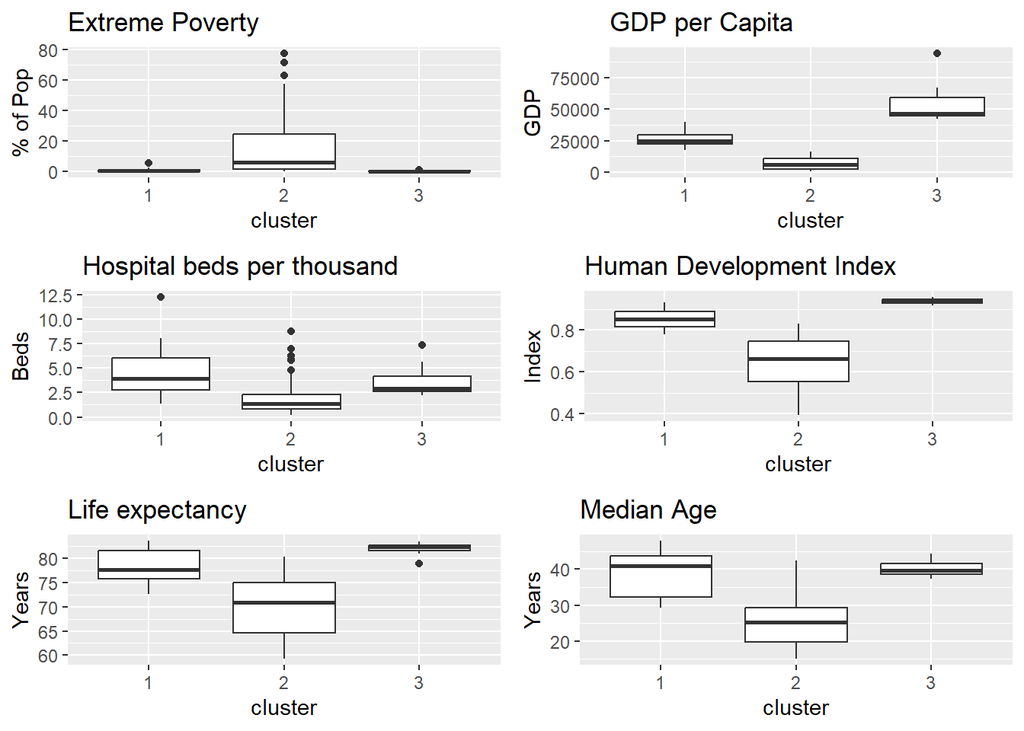

```r
#first, make cluster a factor
df_covid_country$cluster <- as.factor(df_covid_country$cluster)

#then create the plot
plot_hb <- ggplot(df_covid_country, aes(cluster, hospital_beds_per_thousand)) +
  geom_boxplot() +
  labs(title = "Hospital beds per thousand", y ="Beds")

plot_le <- ggplot(df_covid_country, aes(cluster, life_expectancy)) +
  geom_boxplot() +
  labs(title = "Life expectancy", y = "Years")

plot_hdi <- ggplot(df_covid_country, aes(cluster, human_development_index)) +
  geom_boxplot() +
  labs(title = "Human Development Index", y = "Index")

plot_gdp <- ggplot(df_covid_country, aes(cluster, gdp_per_capita)) +
  geom_boxplot() +
  labs(title = "GDP per Capita", y = "GDP")

plot_ep <- ggplot(df_covid_country, aes(cluster, extreme_poverty)) +
  geom_boxplot() +
  labs(title = "Extreme Poverty", y = "% of Pop")

plot_ma <- ggplot(df_covid_country, aes(cluster, median_age)) +
  geom_boxplot() +
  labs(title = "Median Age", y = "Years")

#Visualize all the plots created
cowplot::plot_grid(plot_ep, plot_gdp, plot_hb, plot_hdi, plot_le, plot_ma, ncol = 2, nrow = 3)
```

In order to determine the parameters of each of our clusters, we had to determine the different levels of variables between all of our attributes. The attributes assessed were GDP, HDI, Life Expectancy, Age, Poverty, and Life Expectancy.

Cluster 1:

- Mid Range GDP
- Mid HDI
- Mid Life Expectancy

Cluster 2:

- Low GDP
- Low HDI
- Low Life Expectancy

```r
#Cluster 1 - Red

df_Russia <- df %>%
  filter(location == "Russia")

#Cluster 2 - Green
df_China = df %>%
  filter(location == "China")

#Cluster 3 - USA
```

For the next part of our analysis, there were some distinct countries within each of the clusters as we stated before. We determined that there are different economical levels and other variables between all three of the clusters. However, how does these three clusters compare via cases, deaths, and vaccines? Our next tool will utilize a time lapse graph that shows how the amounts changed for all three scenarios.

### Creating Time Lapse Graphs based on each cluster

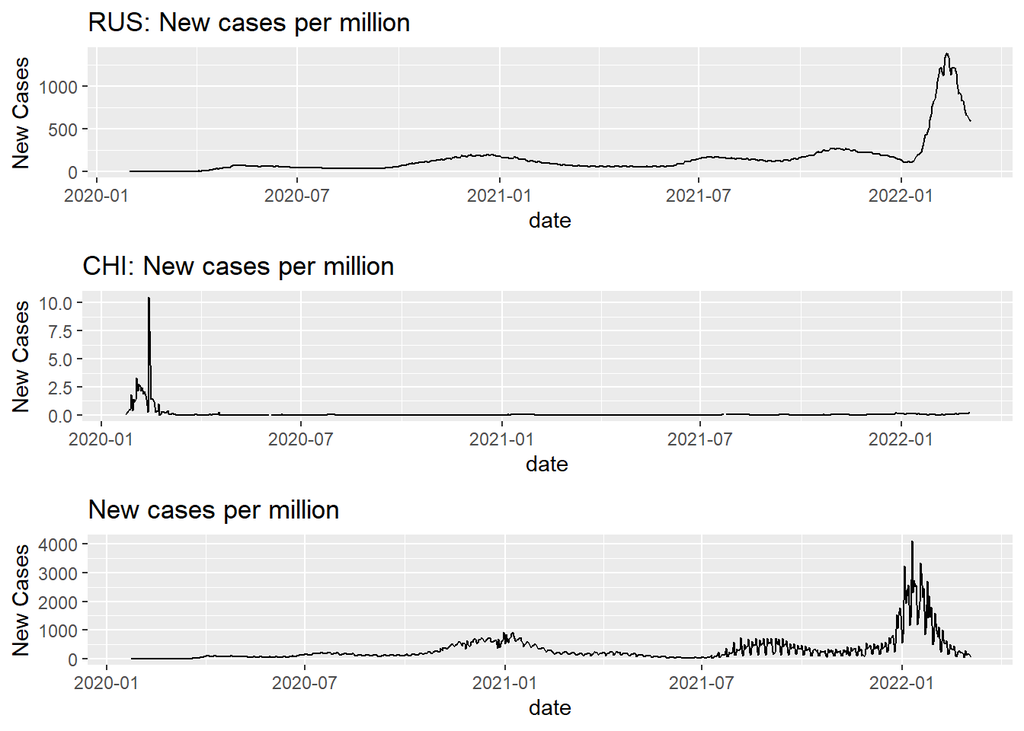

```r
#Time Lapse of Cases per Cluster
tlRus <- ggplot(df_Russia, aes(x = date, y = new_cases_per_million)) +
  geom_line() +
  labs(title = "RUS: New cases per million", y = "New Cases")

tlChi <- ggplot(df_China, aes(x = date, y = new_cases_per_million)) +
  geom_line() +
  labs(title = "CHI: New cases per million", y = "New Cases")

tlUSA <- ggplot(df_USA, aes(x = date, y = new_cases_per_million)) +
  geom_line() +
  labs(title = "New cases per million",
       y = "New Cases")

cowplot::plot_grid(tlRus, tlChi, tlUSA, ncol = 1, nrow = 3)
```

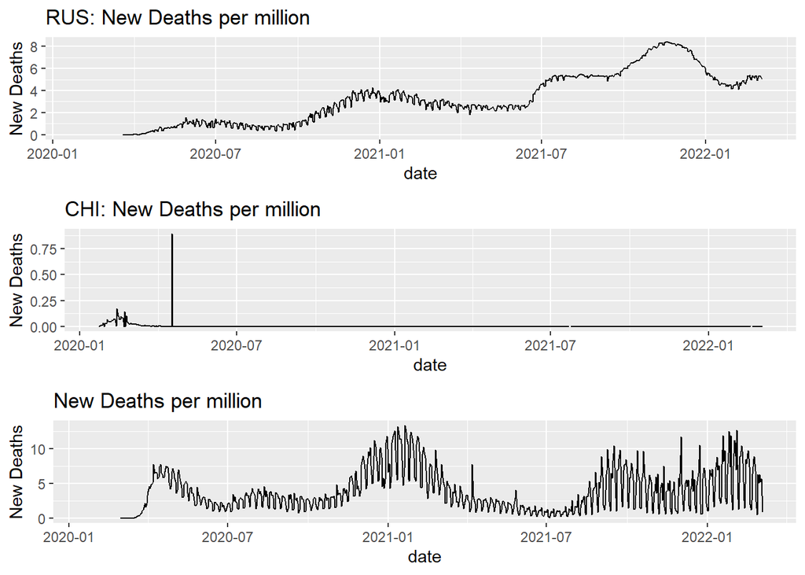

```r
#Time Lapse Deaths per Cluster

tlRus2 <- ggplot(df_Russia, aes(x = date, y = new_deaths_per_million)) +
  geom_line() +
  labs(title = "RUS: New Deaths per million", y = "New Deaths")

tlChi2 <- ggplot(df_China, aes(x = date, y = new_deaths_per_million)) +
  geom_line() +
  labs(title = "CHI: New Deaths per million", y = "New Deaths")

tlUSA2 <- ggplot(df_USA, aes(x = date, y = new_deaths_per_million)) +
  geom_line() +
  labs(title = "New Deaths per million",
       y = "New Deaths")

cowplot::plot_grid(tlRus2, tlChi2, tlUSA2, ncol = 1, nrow = 3)
```

The next timelapse covers the Deaths per million between all three countries. For Russia, it was gradually escalating as time increased. China had a sudden spike of deaths in 2020. Lastly, USA had a peaks and troughs during the whole timeline, varying greatly unlike the others.

[figure not shown]

```r
#Time Lapse Vaccinations per Cluster

tlRus3 <- ggplot(df_Russia, aes(x = date, y = new_vaccinations_smoothed_per_million)) +
  geom_line() +
  labs(title = "RUS: New Vaccinations per million", y = "New Vaccinations")

tlChi3 <- ggplot(df_China, aes(x = date, y = new_vaccinations_smoothed_per_million)) +
  geom_line() +
  labs(title = "CHI: New Vaccionations per million", y = "New Vaccinations")

tlUSA3 <- ggplot(df_USA, aes(x = date, y = new_vaccinations_smoothed_per_million)) +
  geom_line() +
  labs(title = "New Vaccinations per million",
       y = "New Vaccinations")

cowplot::plot_grid(tlRus3, tlChi3, tlUSA3, ncol = 1, nrow = 3)
```

This time lapse graph represents the new number of new vaccinations across all three countries. What is interesting to note is the fact that US had a decreasing number of vaccinations more rapidly than the other two countries.

Times Series for the Cluster Cases

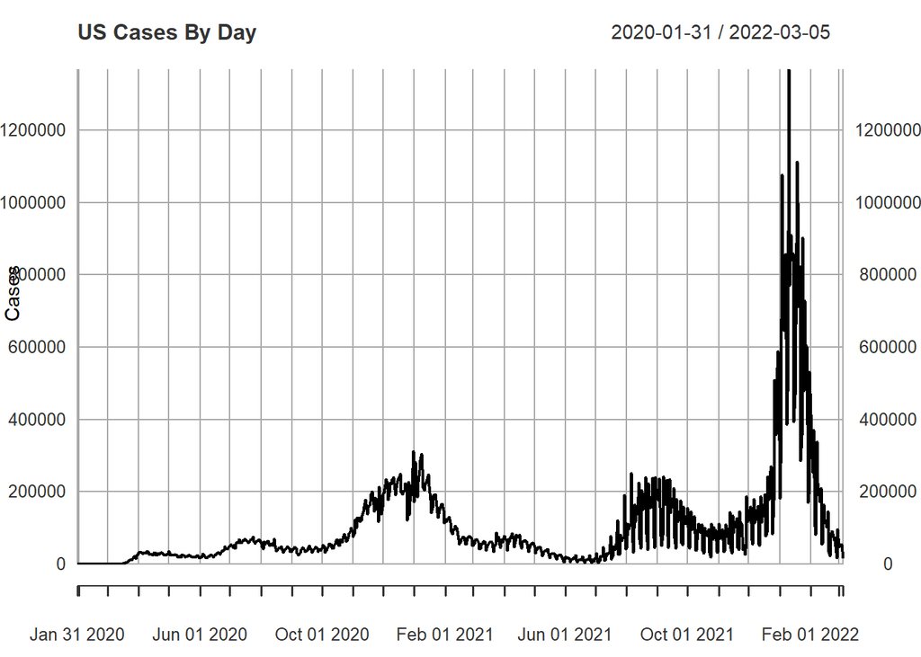

```r
#Dataframe for US Cases
UScases = data.frame(df_USA$new_cases)
UScases = UScases[-(1:9),]

#Data frame for Russia Cases
RusCases = data.frame(df_Russia$new_cases)

#Creating the Start Date and Length
start = as.Date("2020-01-31")
end = as.Date("2022-03-05")
dates = seq(from=start,length=765,by="day")

#Create th Time Series Object
US_case_xts = xts(UScases,order.by = dates)
Rus_case_xts = xts(RusCases,order.by = dates)

#View Time Series
plot(US_case_xts, main="US Cases By Day", xlab = "Date", ylab="Cases")
```

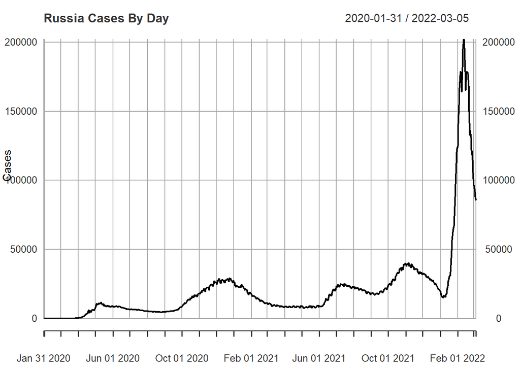

```r
plot(Rus_case_xts,main="Russia Cases By Day",xlab="Date",ylab="Cases")
```

```r
#Difference Analysis
diff_ts <- US_case_xts - Rus_case_xts
diff_ts[27:34]
```

```
##            df_Russia.new_cases
## 2020-02-26                   0
## 2020-02-27                   1
## 2020-02-28                   0
## 2020-02-29                   8
## 2020-03-01                   7
## 2020-03-02                  22
## 2020-03-03                  19
## 2020-03-04                  33
```

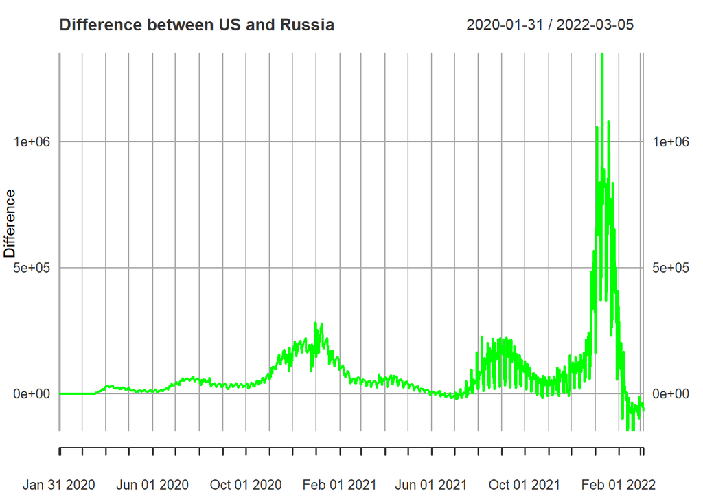

```r
# Plot the difference
plot(diff_ts, type='l', col='green', main='Difference between US and Russia', ylab='Difference', xlab='Date')
```

```r
#Augmented Dickey-Fuller Test
adf.test(US_case_xts)
```

```
##
##  Augmented Dickey-Fuller Test
##
## data:  US_case_xts
## Dickey-Fuller = -3.7465, Lag order = 9, p-value = 0.02167
## alternative hypothesis: stationary
```

```r
adf.test(Rus_case_xts)
```

```
##
##  Augmented Dickey-Fuller Test
##
## data:  Rus_case_xts
## Dickey-Fuller = -6.5077, Lag order = 9, p-value = 0.01
## alternative hypothesis: stationary
```

## Supervised Learning: Data Pre-Processing

### Function for 5-part confusion matrices

In the analyses that follows, several steps will be repeated multiple times, particularly the creation of confusion matrices to assess the accuracy of each model that uses supervised learning. Those steps are defined here as a function, so that later the code can be simplified to one line.

```r
#Function to create a heatmap for the confusion matrix
cmheatmap <- function(cmtitle, cm) {
  ggplot(cm$table, aes(Reference, Prediction, fill= Freq)) +
        geom_tile() + geom_text(aes(label=Freq)) +
        scale_fill_viridis(option = "D", direction = -1) +
        labs(x = "Reference",y = "Prediction") +
        scale_x_discrete(labels= c("Lowest", "Low", "Mid", "High", "Highest")) +
        scale_y_discrete(labels= c("Lowest", "Low", "Mid", "High", "Highest")) +
        labs(title = paste(cmtitle, ": Confusion Matrix"),
             subtitle = paste("Accuracy:", round(cm$overall[1], digits = 2)))
}
```

### Handle NAs

The data included in this analysis has a high level of NA values. This will be further explored below, to identify variables that might be best excluded from the analysis.

```r
#remove aggregate rows (rows that are not representing a country, but a region)
#these all have continent = NA
df <- df %>%
  filter(!is.na(continent))

#keep only data presented as rates (remove raw counts)

df <- df %>%
  select(c(iso_code, continent, location, date, aged_65_older, aged_70_older, cardiovasc_death_rate, diabetes_prevalence, extreme_poverty, female_smokers, gdp_per_capita, handwashing_facilities, human_development_index, life_expectancy, male_smokers, median_age, icu_patients_per_million, hosp_patients_per_million, hospital_beds_per_thousand, population, population_density, stringency_index, reproduction_rate, new_tests_per_thousand, total_tests_per_thousand, positive_rate, tests_per_case, new_cases_per_million, total_cases_per_million, weekly_hosp_admissions_per_million, weekly_icu_admissions_per_million, new_deaths_per_million, total_deaths_per_million, excess_mortality, new_people_vaccinated_smoothed_per_hundred, new_vaccinations_smoothed_per_million, people_fully_vaccinated_per_hundred, people_vaccinated_per_hundred, total_vaccinations_per_hundred, total_boosters_per_hundred))

#identify how much data is missing in each row/ observation
df$blanks <- rowSums(is.na(df))
dim(df)
```

```
## [1] 156370     41
```

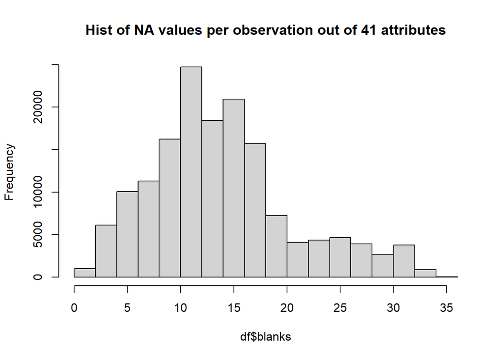

```r
hist(df$blanks, main = "Hist of NA values per observation out of 41 attributes")
```

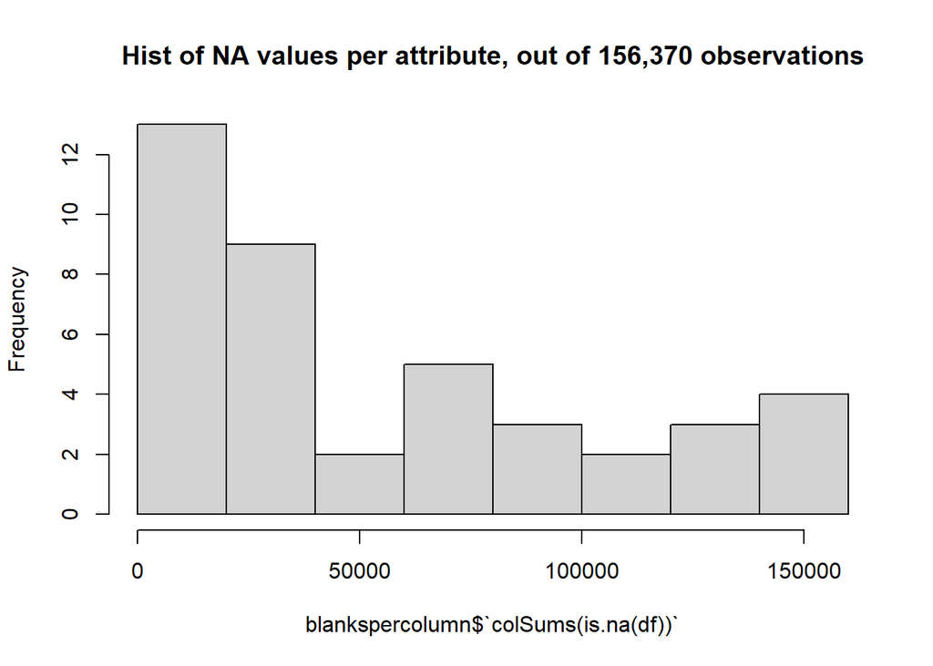

```r
#identify how much data is missing for each column/ attribute
blankspercolumn <- as.data.frame(row.names = colnames(df), x= colSums(is.na(df)))
hist(blankspercolumn$`colSums(is.na(df))`, main = "Hist of NA values per attribute, out of 156,370 observations")
```

```r
#remove rows and columns with a high rate of NAs
df <- df %>%
  filter(blanks < 20) %>%
  select(!blanks) %>%
  select(-c("weekly_icu_admissions_per_million", "excess_mortality", "weekly_hosp_admissions_per_million", "total_boosters_per_hundred"))

#remove the blank counting variable, now that it has been used
rm(blankspercolumn)

#Percent missing values in original table
round(sum(is.na(covid))/(dim(covid)[1] * dim(covid)[2]), 2)
```

```
## [1] 0.45
```

```r
#percent missing values in working table, should be lower
round(sum(is.na(df))/(dim(df)[1] * dim(df)[2]), 2)
```

```
## [1] 0.23
```

```r
#create two copies- one to be further processed for mortality measures
dfm <- df

#create 2nd copy- to be further processed for case measures
dfc <- df
```

### Discretize Mortality

Now that the NAs have been handled, the next step is to discretize the continuous variables for daily mortality rate, and daily case rate. Discretizing these variables into bins will help with the classification analyses later. The data will be split into five equally sized bins based for the lowest, low, mid-level, high, and highest daily mortality rates.

It will also be important, when creating the dataframes to use for predicting either mortality or case rate, to remove any variables that would confound the analysis because they measure the same thing or have an unexpectedly high correlation.

```r
#remove observations that have NAs for the outcome, new_deaths_per_million
dfm <- dfm %>%
  filter(!is.na(dfm$new_deaths_per_million))

#remove columns that are also directly counting mortality, they will be highly correlated
dfm <- dfm %>%
  select(-total_deaths_per_million)

#create a correlation matrix identify if any other columns are highly correlated with new deaths per million
cortable <- as.data.frame(cor(dfm[,5:35], use="pairwise.complete.obs"))
cortable <- data.frame(rownames(cortable), cortable$new_deaths_per_million)

#view the most highly correlated values (both positive and negative correlations)
cortable %>% arrange(desc(cortable.new_deaths_per_million)) %>% head()
```

|  | rownames.cortable. | cortable.new_deaths_per_million |
| --- | --- | --- |
| 1 | new_deaths_per_million | 1.0000000 |
| 2 | hosp_patients_per_million | 0.7545382 |
| 3 | icu_patients_per_million | 0.6797224 |
| 4 | positive_rate | 0.3392411 |
| 5 | total_cases_per_million | 0.2814994 |
| 6 | new_cases_per_million | 0.2805024 |

```r
cortable %>% arrange(cortable.new_deaths_per_million) %>% head()
```

|  | rownames.cortable. | cortable.new_deaths_per_million |
| --- | --- | --- |
| 1 | extreme_poverty | -0.23878717 |
| 2 | people_fully_vaccinated_per_hundred | -0.10178745 |
| 3 | people_vaccinated_per_hundred | -0.08798342 |
| 4 | total_vaccinations_per_hundred | -0.08335716 |
| 5 | population_density | -0.04324888 |
| 6 | population | -0.04231961 |

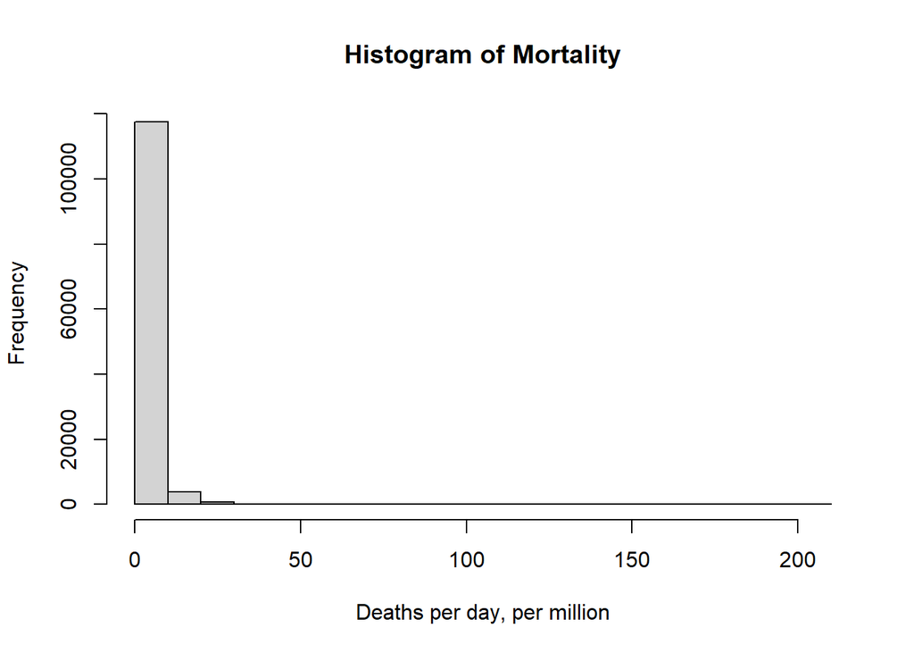

```r
#view the distribution of new deaths per million in this dataset
hist(dfm$new_deaths_per_million, main = "Histogram of Mortality", xlab = "Deaths per day, per million")
```

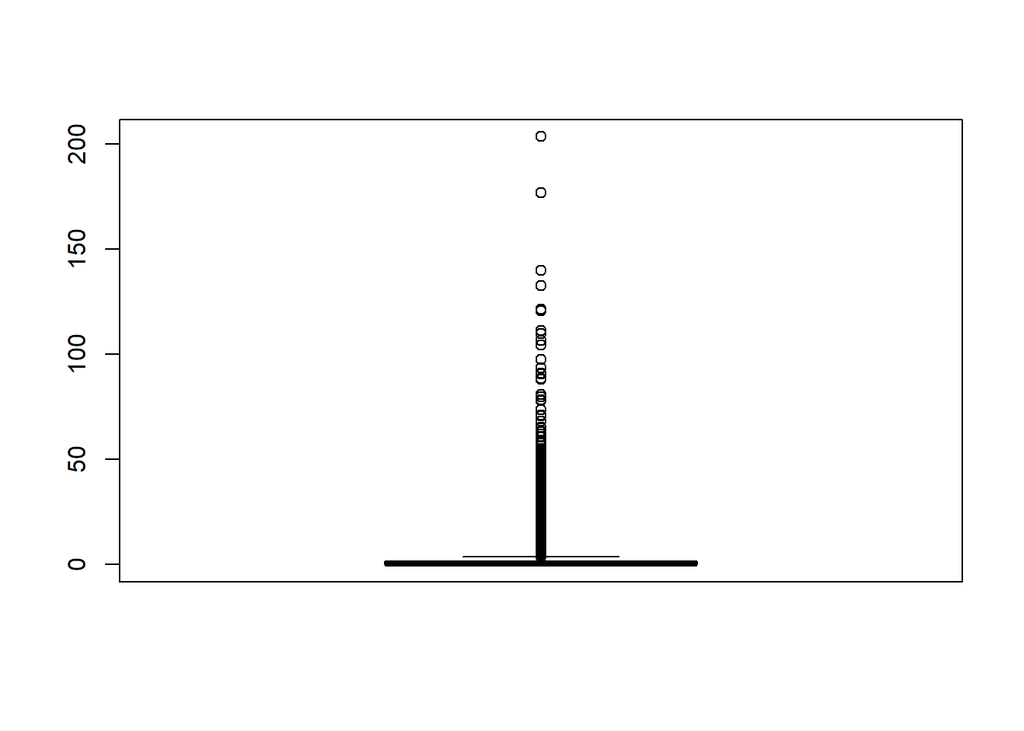

```r
boxplot(dfm$new_deaths_per_million)
```

```r
summary(dfm$new_deaths_per_million)
```

```
##    Min. 1st Qu.  Median    Mean 3rd Qu.    Max.
##   0.000   0.000   0.159   1.650   1.491 203.513
```

```r
#discretize into 5 categories, roughly equal sized (except the lowest one is large)
deathcategory <- arules::discretize(dfm$new_deaths_per_million,
                                    method = "frequency",
                                    breaks = 7,
                                    ordered_result = TRUE,
                                    labels = c("Lowest (0-0.1)", "Low (0.1-0.5)", "Mid (0.5-1.3)", "High (1.3-3.8)", "Highest (>3.8)"))
```

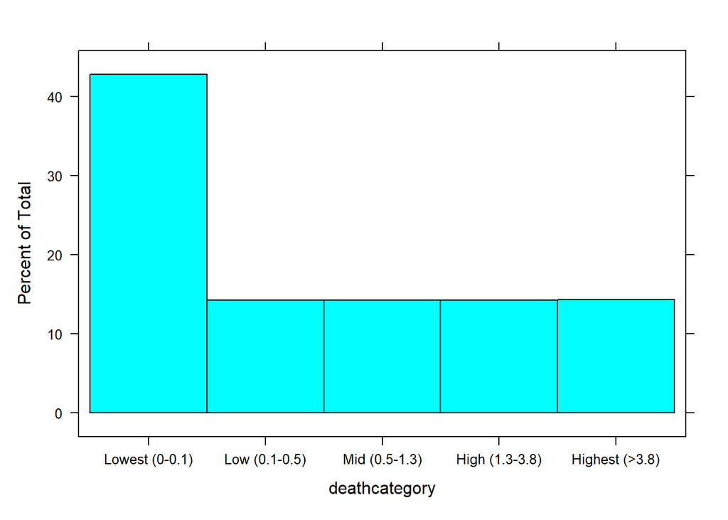

```r
histogram(deathcategory)
```

```r
#add the discretization to the main table
dfm$deathcategory <- deathcategory

#remove new deaths per million so that's not used in the analysis (we only want the discretized factor)
dfm <- dfm %>% select(-new_deaths_per_million)

#Split into test and train
set.seed(92)
dfm_training <- sample_frac(dfm, .7)
suppressMessages(dfm_testing <- anti_join(dfm, dfm_training))

#create new tables that don't have the country, month, or actual death number
dfm_training <- dfm_training[,5:35]
dfm_testing <- dfm_testing[,5:35]
```

Above it can be seen that when discretizing the data by mortality rate, even when setting the bins to be of equal size, the first bin, representing the lowest daily death rate, is larger. This is because, as seen previously in the analysis, the data has a heavy right skew with most of the values falling below 1.

### Discretize Cases

Next, a similar process will be followed to discretize the daily case rate as well. Again, the data will be reviewed for any variables that are highly correlated, and then discretized into five roughly equally sized bins for use in classification algorithms.

```r
#remove observations that do not have new_cases_per_million
dfc <- dfc %>%
  filter(!is.na(dfc$new_cases_per_million))

#remove columns that are also counting cases in different ways (or are downstream from case counts, such as death counts)
dfc <- dfc %>%
  select(-c(total_cases_per_million, new_deaths_per_million, total_deaths_per_million, positive_rate, tests_per_case))

#create a correlation matrix identify if any other columns are highly correlated with new cases per million
cortablec <- as.data.frame(cor(dfc[,5:31], use="pairwise.complete.obs"))
cortablec <- data.frame(rownames(cortablec), cortablec$new_cases_per_million)

#view the most highly correlated values (both positive and negative correlations)
cortablec %>% arrange(desc(cortablec.new_cases_per_million)) %>% head()
```

|  | rownames.cortablec. | cortablec.new_cases_per_million |
| --- | --- | --- |
| 1 | new_cases_per_million | 1.0000000 |
| 2 | total_tests_per_thousand | 0.3555330 |
| 3 | total_vaccinations_per_hundred | 0.3316727 |
| 4 | new_tests_per_thousand | 0.3233979 |
| 5 | people_fully_vaccinated_per_hundred | 0.2942850 |
| 6 | people_vaccinated_per_hundred | 0.2649318 |

```r
cortablec %>% arrange(cortablec.new_cases_per_million) %>% head()
```

|  | rownames.cortablec. | cortablec.new_cases_per_million |
| --- | --- | --- |
| 1 | extreme_poverty | -0.162261236 |
| 2 | cardiovasc_death_rate | -0.101824363 |
| 3 | new_people_vaccinated_smoothed_per_hundred | -0.043281922 |
| 4 | population | -0.042096084 |
| 5 | stringency_index | -0.003506507 |
| 6 | population_density | 0.015770661 |

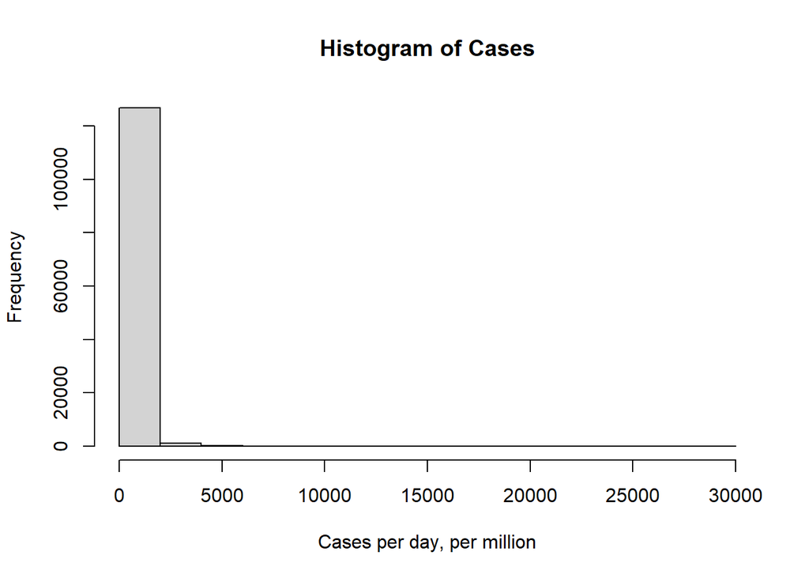

```r
#view the distribution of new cases per million in this dataset
hist(dfc$new_cases_per_million, main = "Histogram of Cases", xlab = "Cases per day, per million")
```

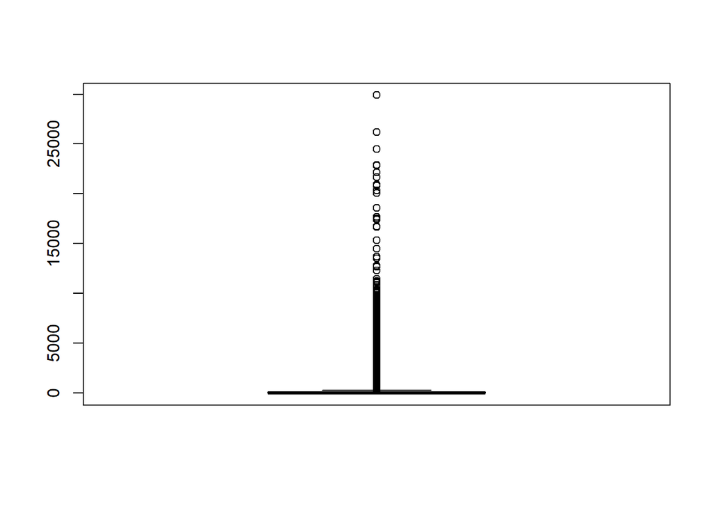

```r
boxplot(dfc$new_cases_per_million)
```

```r
summary(dfc$new_cases_per_million)
```

```
##      Min.   1st Qu.    Median      Mean   3rd Qu.      Max.
##     0.000     0.671    15.184   159.935   111.384 29901.492
```

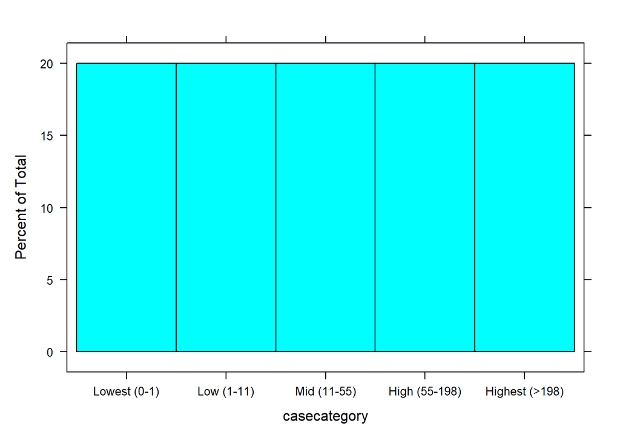

```r
#discretize
casecategory <- arules::discretize(dfc$new_cases_per_million,
                                   method = "frequency",
                                   breaks = 5,
                                   ordered_result = TRUE,
                                   labels = c("Lowest (0-1)", "Low (1-11)", "Mid (11-55)", "High (55-198)", "Highest (>198)"))

#view the distribution of cases
histogram(casecategory)
```

```r
#add the discretization to the main table
dfc$casecategory <- casecategory

#remove new cases per million so that's not used in the analysis
dfc <- dfc %>% select(-new_cases_per_million)

#Split Case data set into test & train
set.seed(92)
dfc_training <- sample_frac(dfc, .7)
suppressMessages(dfc_testing <- anti_join(dfc, dfc_training))

#create new tables that don't have the country, month, or actual case number
dfc_training <- dfc_training[,5:31]
dfc_testing <- dfc_testing[,5:31]
```

### Create “Complete Cases” table

Some machine learning algorithms perform best when there is no missing data. In anticipation of that, another dataframe will be created that excludes certain variables with a high NA rate, and then removes any observations that are missing data.

```r
#remove rows and columns with a high rate of NAs
dfc_cc_testing <- dfc_testing %>%
  select(-c("extreme_poverty", "handwashing_facilities", "icu_patients_per_million", "hosp_patients_per_million"))

dfc_cc_training <- dfc_training %>%
  select(-c("extreme_poverty", "handwashing_facilities", "icu_patients_per_million", "hosp_patients_per_million"))


dfc_cc_testing <- dfc_cc_testing[complete.cases(dfc_cc_testing), ]

dfc_cc_training <- dfc_cc_training[complete.cases(dfc_cc_training), ]


#remove rows and columns with a high rate of NAs
dfm_cc_testing  <- dfm_testing %>%
  select(-c("extreme_poverty", "handwashing_facilities", "icu_patients_per_million", "hosp_patients_per_million"))

dfm_cc_training  <- dfm_training %>%
  select(-c("extreme_poverty", "handwashing_facilities", "icu_patients_per_million", "hosp_patients_per_million"))


dfm_cc_testing  <- dfm_cc_testing [complete.cases(dfm_cc_testing ), ]

dfm_cc_training  <- dfm_cc_training [complete.cases(dfm_cc_training ), ]
```

## K Nearest Neighbor

At this point, the data has been thoroughly pre-processed and is ready for use in machine learning analyses. The first model assessed will be K Nearest Neighbor.

### Cases

K nearest neighbor is a supervised machine learning model that works well with classification problems. This model is considered “instance based learning” or “lazy learning” because it does not actually develop a model. Instead, when given a testing data set, it scans the training dataset to find the “nearest neighbors” (the observations that are most similar to to testing data), and then takes the classification that is most common amongst those neighbors. The main parameter to tune here is the value for K, which is the number of observations that are counted as neighbors. The plot below shows that the best number of neighbors to use for this particular dataset is 7.

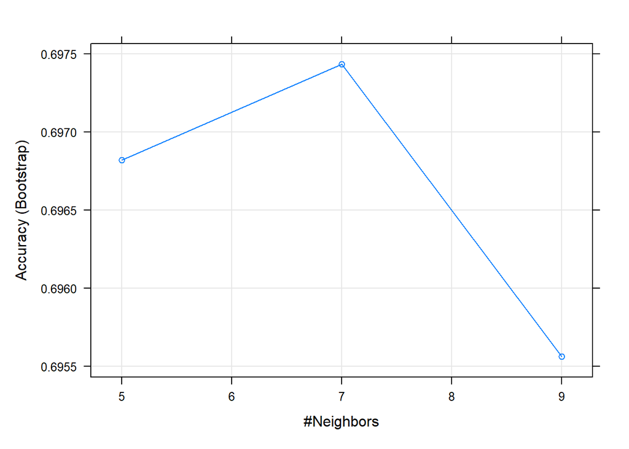

```r
#Create the KNN model
knnc_model <- caret::train(
  casecategory~.,
  data = dfc_cc_training,
  method = "knn",
  na.action = na.omit
)

#plot the tuned model to see accuracy against number of neighbors tested
plot(knnc_model) #best number of neighbors was 7
```

```r
#create predictions on the training data
knnc_training_predictions <- predict(knnc_model, dfc_cc_training)

#use a confusion matrix to assess accuracy on training data
knnc_training_cnfsmtrx <- confusionMatrix(dfc_cc_training$casecategory, knnc_training_predictions)
knnc_training_cnfsmtrx$overall[1]
```

```
##  Accuracy
## 0.7925773
```

The Confusion Matrix below shows that this model is able to predict the daily case rate with a 73% accuracy level.

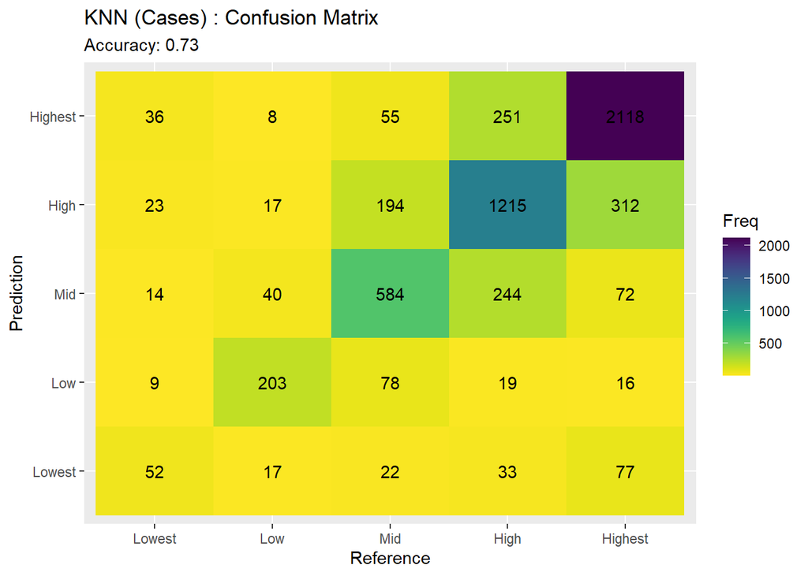

```r
#create predictions on the testing data
knnc_testing_predictions <- predict(knnc_model, dfc_cc_testing)

#use a confusion matrix to assess
knnc_testing_cnfsmtrx <- confusionMatrix(dfc_cc_testing$casecategory, knnc_testing_predictions)

#visualize the confusion matrix on the testing data
cmheatmap("KNN (Cases)", knnc_testing_cnfsmtrx)
```